# Appendix: OSDH Maps

**Report Description**: Show the geographical relationships and patterns in administrative and demographic variables

## 1. C1 'Lead Nurse' Regions

With the exception of the two large urban counties (ie, Tulsa and Oklahoma Counties), a “lead nurse” oversees nurses in several counties. The non-urban counties are managed by 18 lead nurses. We are calling these areas “Lead Nurse Regions”, and are numbering them 1 through 18. Oklahoma County is 19, and Tulsa County is 20. Note that multiple lead nurses operate in each urban county, but we are assigning a single region to each county.

A county's region assignment is listed in the legend, and below its name in the map. Each region has a unique color below; these color assignements are used for the lead nurse regions in other reports.

Of the state's 77 counties, 51 receive C1 funding; these are labeled in black. The remaining 26 unfunded counties have asteristics, and are labeled in gray.

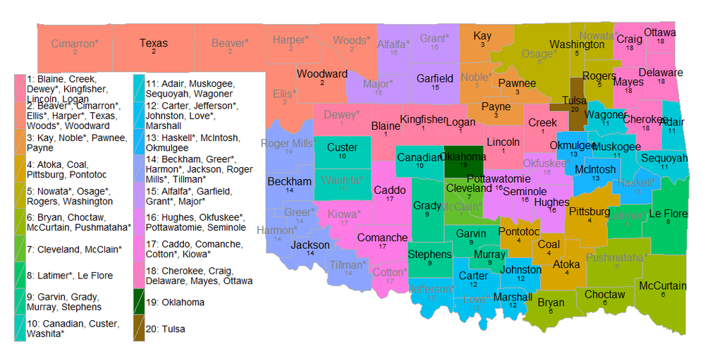

## 2. MEICHV Community Survey Counties

The Community Survey, administered by the MIECHV External Evaulation Team, samples from residents of the four counties below. The sampling frame is created creating a list from eligible WIC and Medicaid recipients.

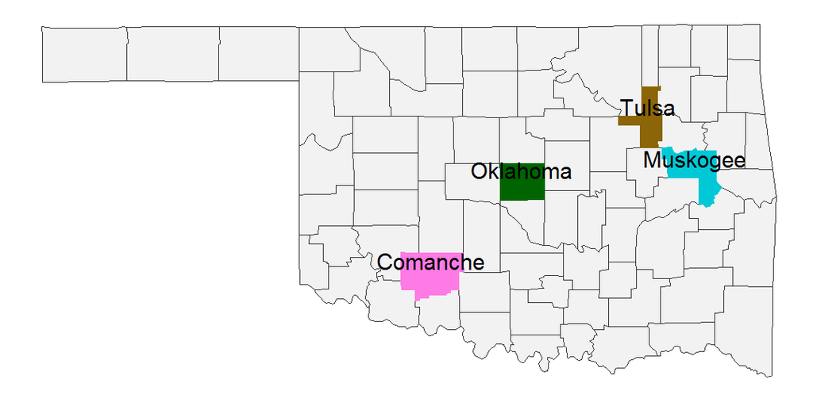

## 3. Population

For reference, here are the county populations as of 2010. A topographical color scheme represents the number of people; greener values represent a lower population/elevation. A county's population (in thousands) is labeled on the map.

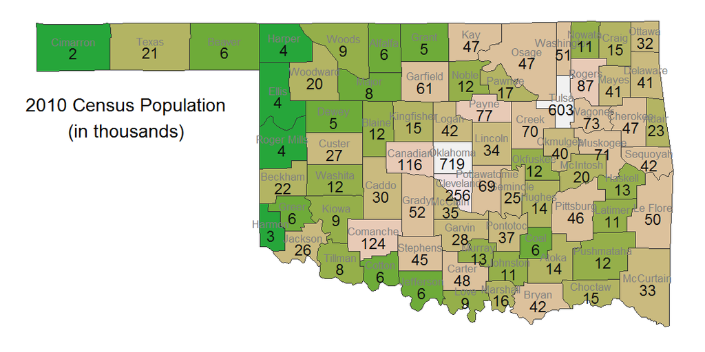

## 4. WIC Need

For reference, here are percentage of county residents in need. A 2010 WIC county estimate (that consider the number of women, children, and infants) is divided by the 2010 Census county population. A topographical color scheme represents the percent of of people; greener values represent a lower need/elevation. A county's percentage is labeled on the map.

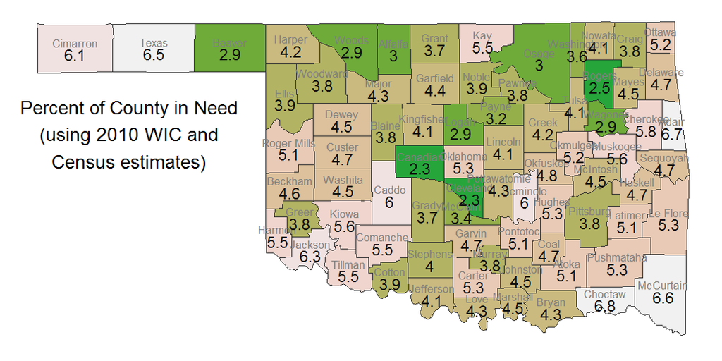

## 5. Demographics across Lead Nurse Regions and Counties

Here are some demographics for the C1 Lead Nurse Regions, using WIC's estimates of the total population need. Notice that some reports use the more selective Infants in Need' instead. The final column is the percentage of the population in need. Counties with an asterisk do not receive C1 funding.

| Region | Counties | Pop Total | Pop in Need | Need % |
| --- | --- | --- | --- | --- |
| 1 | Blaine, Creek, Dewey*, Kingfisher, Lincoln, Logan | 177,875 | 6,847 | 3.8% |
| 2 | Beaver*, Cimarron*, Ellis*, Harper*, Texas, Woods*, Woodward | 65,546 | 2,996 | 4.6% |
| 3 | Kay, Noble*, Pawnee, Payne | 152,050 | 6,110 | 4.0% |
| 4 | Atoka, Coal, Pittsburg, Pontotoc | 103,436 | 4,649 | 4.5% |
| 5 | Nowata*, Osage*, Rogers, Washington | 195,889 | 5,896 | 3.0% |
| 6 | Bryan, Choctaw, McCurtain, Pushmataha* | 102,344 | 5,662 | 5.5% |
| 7 | Cleveland, McClain* | 290,261 | 6,929 | 2.4% |
| 8 | Latimer*, Le Flore | 61,538 | 3,253 | 5.3% |
| 9 | Garvin, Grady, Murray, Stephens | 138,543 | 5,508 | 4.0% |
| 10 | Canadian, Custer, Washita* | 154,639 | 4,510 | 2.9% |
| 11 | Adair, Muskogee, Sequoyah, Wagoner | 209,149 | 9,617 | 4.6% |
| 12 | Carter, Jefferson*, Johnston, Love*, Marshall | 90,249 | 4,381 | 4.9% |
| 13 | Haskell*, McIntosh, Okmulgee | 73,090 | 3,607 | 4.9% |
| 14 | Beckham, Greer*, Harmon*, Jackson, Roger Mills*, Tillman* | 69,365 | 3,707 | 5.3% |
| 15 | Alfalfa*, Garfield, Grant*, Major* | 78,276 | 3,315 | 4.2% |
| 16 | Hughes, Okfuskee*, Pottawatomie, Seminole | 121,118 | 5,829 | 4.8% |
| 17 | Caddo, Comanche, Cotton*, Kiowa* | 169,337 | 9,439 | 5.6% |
| 18 | Cherokee, Craig, Delaware, Mayes, Ottawa | 176,610 | 8,741 | 4.9% |
| 19 | Oklahoma | 718,633 | 37,921 | 5.3% |
| 20 | Tulsa | 603,403 | 24,746 | 4.1% |

Here a some demographics for Oklahoma's funded and unfunded counties, using WIC's estimates of need.

| ID | County | Lead Nurse Region | C1 | Pop Total | Pop in Need | Need % |
| --- | --- | --- | --- | --- | --- | --- |
| 1 | Adair | 11 | Y | 22,683 | 1,526 | 6.7% |
| 2 | Alfalfa | 15 | - | 5,642 | 172 | 3.0% |
| 3 | Atoka | 4 | Y | 14,182 | 730 | 5.1% |
| 4 | Beaver | 2 | - | 5,636 | 166 | 2.9% |
| 5 | Beckham | 14 | Y | 22,119 | 1,007 | 4.6% |
| 6 | Blaine | 1 | Y | 11,943 | 457 | 3.8% |
| 7 | Bryan | 6 | Y | 42,416 | 1,830 | 4.3% |
| 8 | Caddo | 17 | Y | 29,600 | 1,778 | 6.0% |
| 9 | Canadian | 10 | Y | 115,541 | 2,704 | 2.3% |
| 10 | Carter | 12 | Y | 47,557 | 2,508 | 5.3% |
| 11 | Cherokee | 18 | Y | 46,987 | 2,705 | 5.8% |
| 12 | Choctaw | 6 | Y | 15,205 | 1,032 | 6.8% |
| 13 | Cimarron | 2 | - | 2,475 | 152 | 6.1% |
| 14 | Cleveland | 7 | Y | 255,755 | 5,760 | 2.3% |
| 15 | Coal | 4 | Y | 5,925 | 277 | 4.7% |
| 16 | Comanche | 17 | Y | 124,098 | 6,886 | 5.5% |
| 17 | Cotton | 17 | - | 6,193 | 242 | 3.9% |
| 18 | Craig | 18 | Y | 15,029 | 566 | 3.8% |
| 19 | Creek | 1 | Y | 69,967 | 2,919 | 4.2% |
| 20 | Custer | 10 | Y | 27,469 | 1,279 | 4.7% |
| 21 | Delaware | 18 | Y | 41,487 | 1,946 | 4.7% |
| 22 | Dewey | 1 | - | 4,810 | 218 | 4.5% |
| 23 | Ellis | 2 | - | 4,151 | 163 | 3.9% |
| 24 | Garfield | 15 | Y | 60,580 | 2,653 | 4.4% |
| 25 | Garvin | 9 | Y | 27,576 | 1,287 | 4.7% |
| 26 | Grady | 9 | Y | 52,431 | 1,922 | 3.7% |
| 27 | Grant | 15 | - | 4,527 | 169 | 3.7% |
| 28 | Greer | 14 | - | 6,239 | 238 | 3.8% |
| 29 | Harmon | 14 | - | 2,922 | 162 | 5.5% |
| 30 | Harper | 2 | - | 3,685 | 155 | 4.2% |
| 31 | Haskell | 13 | - | 12,769 | 602 | 4.7% |
| 32 | Hughes | 16 | Y | 14,003 | 740 | 5.3% |
| 33 | Jackson | 14 | Y | 26,446 | 1,674 | 6.3% |
| 34 | Jefferson | 12 | - | 6,472 | 267 | 4.1% |
| 35 | Johnston | 12 | Y | 10,957 | 491 | 4.5% |
| 36 | Kay | 3 | Y | 46,562 | 2,548 | 5.5% |
| 37 | Kingfisher | 1 | Y | 15,034 | 623 | 4.1% |
| 38 | Kiowa | 17 | - | 9,446 | 533 | 5.6% |
| 39 | Latimer | 8 | - | 11,154 | 564 | 5.1% |
| 40 | Le Flore | 8 | Y | 50,384 | 2,689 | 5.3% |
| 41 | Lincoln | 1 | Y | 34,273 | 1,412 | 4.1% |
| 42 | Logan | 1 | Y | 41,848 | 1,218 | 2.9% |
| 43 | Love | 12 | - | 9,423 | 407 | 4.3% |
| 44 | McClain | 7 | - | 34,506 | 1,169 | 3.4% |
| 45 | McCurtain | 6 | Y | 33,151 | 2,189 | 6.6% |
| 46 | McIntosh | 13 | Y | 20,252 | 913 | 4.5% |
| 47 | Major | 15 | - | 7,527 | 321 | 4.3% |
| 48 | Marshall | 12 | Y | 15,840 | 708 | 4.5% |
| 49 | Mayes | 18 | Y | 41,259 | 1,859 | 4.5% |
| 50 | Murray | 9 | Y | 13,488 | 516 | 3.8% |
| 51 | Muskogee | 11 | Y | 70,990 | 3,983 | 5.6% |
| 52 | Noble | 3 | - | 11,561 | 447 | 3.9% |
| 53 | Nowata | 5 | - | 10,536 | 434 | 4.1% |
| 54 | Okfuskee | 16 | - | 12,191 | 589 | 4.8% |
| 55 | Oklahoma | 19 | Y | 718,633 | 37,921 | 5.3% |
| 56 | Okmulgee | 13 | Y | 40,069 | 2,092 | 5.2% |
| 57 | Osage | 5 | - | 47,472 | 1,436 | 3.0% |
| 58 | Ottawa | 18 | Y | 31,848 | 1,665 | 5.2% |
| 59 | Pawnee | 3 | Y | 16,577 | 635 | 3.8% |
| 60 | Payne | 3 | Y | 77,350 | 2,480 | 3.2% |
| 61 | Pittsburg | 4 | Y | 45,837 | 1,725 | 3.8% |
| 62 | Pontotoc | 4 | Y | 37,492 | 1,917 | 5.1% |
| 63 | Pottawatomie | 16 | Y | 69,442 | 2,983 | 4.3% |
| 64 | Pushmataha | 6 | - | 11,572 | 611 | 5.3% |
| 65 | Roger Mills | 14 | - | 3,647 | 185 | 5.1% |
| 66 | Rogers | 5 | Y | 86,905 | 2,185 | 2.5% |
| 67 | Seminole | 16 | Y | 25,482 | 1,517 | 6.0% |
| 68 | Sequoyah | 11 | Y | 42,391 | 1,989 | 4.7% |
| 69 | Stephens | 9 | Y | 45,048 | 1,783 | 4.0% |
| 70 | Texas | 2 | Y | 20,640 | 1,350 | 6.5% |
| 71 | Tillman | 14 | - | 7,992 | 441 | 5.5% |
| 72 | Tulsa | 20 | Y | 603,403 | 24,746 | 4.1% |
| 73 | Wagoner | 11 | Y | 73,085 | 2,119 | 2.9% |
| 74 | Washington | 5 | Y | 50,976 | 1,841 | 3.6% |
| 75 | Washita | 10 | - | 11,629 | 527 | 4.5% |
| 76 | Woods | 2 | - | 8,878 | 256 | 2.9% |
| 77 | Woodward | 2 | Y | 20,081 | 754 | 3.8% |

# Session Information

For the sake of documentation and reproducibility, the current report was build on a system using the following software.

```
## Report rendered by Will at Sat Jun 21 22:56:45 2014
```